# *Notebook NLP*

## Sommaire

1. Import des librairies
2. Chargement des données
3. Nettoyage et analyse des reviews
4. Vectorisation
5. Topic Modeling avec LDA (Latent Dirichlet Allocation)

## Import des librairies

```python
%reload_ext autoreload
%autoreload 2
%matplotlib inline

import pandas as pd
import nltk
from nltk.corpus import stopwords
nltk.download('stopwords')
nltk.download('wordnet')
nltk.download('omw-1.4')
nltk.download('averaged_perceptron_tagger')
from nltk.stem import WordNetLemmatizer
import emoji

from wordcloud import WordCloud

from gensim import models
from gensim.corpora.dictionary import Dictionary

# Plotting tools
import pyLDAvis
import pyLDAvis.gensim_models  # don't skip this
import matplotlib.pyplot as plt

from sklearn.feature_extraction.text import CountVectorizer, TfidfVectorizer

# Import des modules contenant les fonctions utilitaires
import src.data_helpers as dth
```

```python
# Réglage des graphiques
plt.style.use('seaborn-whitegrid')

plt.rc('font', size=12)
plt.rc('axes', titlesize=20)
plt.rc('axes', labelsize=20)
plt.rc('xtick', labelsize=12)
plt.rc('ytick', labelsize=12)
plt.rc('legend', fontsize=12)

dims_fig = (25,20)
```

## Chargement des données

On recupère le jeu de données sauvegardé à la fin de l'analyse et de la manipulation des données, ansi que celui récupéré via l'API, puis on les fusionne.

```python
# Jeu de données recupéré via l'API
bad_reviews_api = pd.read_csv('bad_reviews_from_api.csv', sep=',')
```

```python
dth.displayDataShape('Le fichier bad_reviews_api contient', bad_reviews_api)
```

```
Le fichier bad_reviews_api contient : 21 lignes et 4 colonnes
```

```python
bad_reviews_api.head()
```

|  | business_id | categories | stars | text |
| --- | --- | --- | --- | --- |
| 0 | 4yPqqJDJOQX69gC66YUDkA | Restaurants | 1 | Really don't see the hype. Came here for lun... |
| 1 | vRrVSB-LegwUwIxpkeRVtQ | Restaurants | 1 | As a long time fan of Chef Eric Ripert and a w... |
| 2 | nI1UYDCYUTt23TpGxqnLKg | Restaurants | 1 | I have been coming to Buddakan since I moved t... |
| 3 | 1DfbZ0VsSCg9g1KILmnvzQ | Restaurants | 1 | Possibly the worst splurge meal I've had in my... |
| 4 | M6qUGNq8_25RUs8Q9KcLaQ | Restaurants | 1 | My review unfortunately will not be covering t... |

```python
# Jeu de données issu de l'analyse
bad_reviews = pd.read_csv('bad_reviews.csv', sep=',')
```

```python
dth.displayDataShape('Le fichier bad_reviews contient', bad_reviews)
```

```
Le fichier bad_reviews contient : 618063 lignes et 4 colonnes
```

```python
bad_reviews.head()
```

|  | business_id | categories | stars | text |
| --- | --- | --- | --- | --- |
| 0 | MTSW4McQd7CbVtyjqoe9mw | Restaurants, Food, Bubble Tea, Coffee & Tea, B... | 1.0 | Horrible 3rd world service. After I picked out... |
| 1 | MTSW4McQd7CbVtyjqoe9mw | Restaurants, Food, Bubble Tea, Coffee & Tea, B... | 1.0 | Looks like a nice place from the outside, but ... |
| 2 | MTSW4McQd7CbVtyjqoe9mw | Restaurants, Food, Bubble Tea, Coffee & Tea, B... | 1.0 | bun is sucked here and the waitress was really... |
| 3 | MTSW4McQd7CbVtyjqoe9mw | Restaurants, Food, Bubble Tea, Coffee & Tea, B... | 1.0 | TERRIBLE TERRIBLE service. I have never felt s... |
| 4 | MTSW4McQd7CbVtyjqoe9mw | Restaurants, Food, Bubble Tea, Coffee & Tea, B... | 1.0 | Not sure what happen. I have order a taro cake... |

```python
# On merge ensemble les 2 jeux de données
merge_bad_reviews = pd.concat([bad_reviews, bad_reviews_api])
dth.displayDataShape('Le fichier bad_reviews contient', merge_bad_reviews)
```

```
Le fichier bad_reviews contient : 618084 lignes et 4 colonnes
```

Pour limiter les temps de calcul par la suite, on ne garde que 50 000 reviews choisies aléatoirement.

```python
sample_reviews = merge_bad_reviews.sample(n = 50000)
sample_reviews
```

|  | business_id | categories | stars | text |
| --- | --- | --- | --- | --- |
| 211307 | 12SbnXfsthBbBaF2YzhLfA | Tex-Mex, Bars, American (Traditional), Restaur... | 1.0 | Terrible experience. The servers are the worse... |
| 120646 | xWb-YZ1qoDwJYYpyONQciA | Restaurants, Pubs, Cocktail Bars, Pizza, Ameri... | 1.0 | Used to be good but not anymore. Took away or ... |
| 242312 | uPngSFlKQmQT3v8h8aTwmA | Pizza, Restaurants | 1.0 | Ordered a medium plain cheese pizza. Brought i... |
| 505613 | NAMen7YzwlYDs_5ECMnuYQ | Food, Comfort Food, Nightlife, Restaurants, Ba... | 1.0 | I came to this place a month or so ago and it ... |
| 433332 | 2fJ-WxJlUN6azp3bzrJ0zA | Restaurants, Chinese, Vietnamese | 1.0 | SUCKED, They forgot my order and I found out 2... |
| ... | ... | ... | ... | ... |
| 511681 | YrNtBUOUOYwmRZ_UVwH8iQ | Restaurants, Food, Breakfast & Brunch, Bakeries | 1.0 | First and last visit. Overpriced.......eggs B... |
| 296448 | R8WaL2GBd6FIFHmwaRWGNQ | American (Traditional), Restaurants, Burgers, ... | 1.0 | :( I was excited to come but was literally let... |
| 421907 | Sf_hAk2T3_3-sgpF0gl2lw | Salad, Sandwiches, Breakfast & Brunch, America... | 1.0 | Went in to ask a question after being a patron... |
| 596711 | l3zSx4cXpSOiUnEbjY1TxA | Restaurants, Fast Food, Burgers | 1.0 | If I could give these ignorant people negative... |
| 164978 | _HszLv9iG-jRCXmFsSRBSw | Grocery, Food, Food Delivery Services | 1.0 | I should have checked here before having them ... |

50000 rows × 4 columns

## Nettoyage et analyse des reviews

On va commencer par créer une première fonction afin de nettoyer les reviews de notre data de cette manière :

- Remplacement des emojis par son équivalent en mot
- Suppression de la ponctuation et des nombres
- Mettre le texte en minuscule
- Tokenizer notre texte (un token = 1 mot, chaque review est donc sous la forme d'un tableau de mots (de tokens))

```python
tokenizer = nltk.RegexpTokenizer(r'[a-zA-Z]+')

# Notre fonction de nettoyage et de tokenization
def tokenize_text(text):
    return tokenizer.tokenize(emoji.demojize(text, delimiters=("", "")).lower())
```

1er Nettoyage :

```python
# Création d'un corpus de tokens
corpus = []
for row in sample_reviews.index:
    corpus.append(tokenize_text(sample_reviews['text'][row]))

# Calcul des fréquences des mots dans chaque texte
freq = []
for row in corpus:
    freq.append(nltk.FreqDist(row))

# Fréquence totale de chaque mot pour l'ensemble du corpus
freq_totale = nltk.Counter()
for fr in freq:
    freq_totale += fr
```

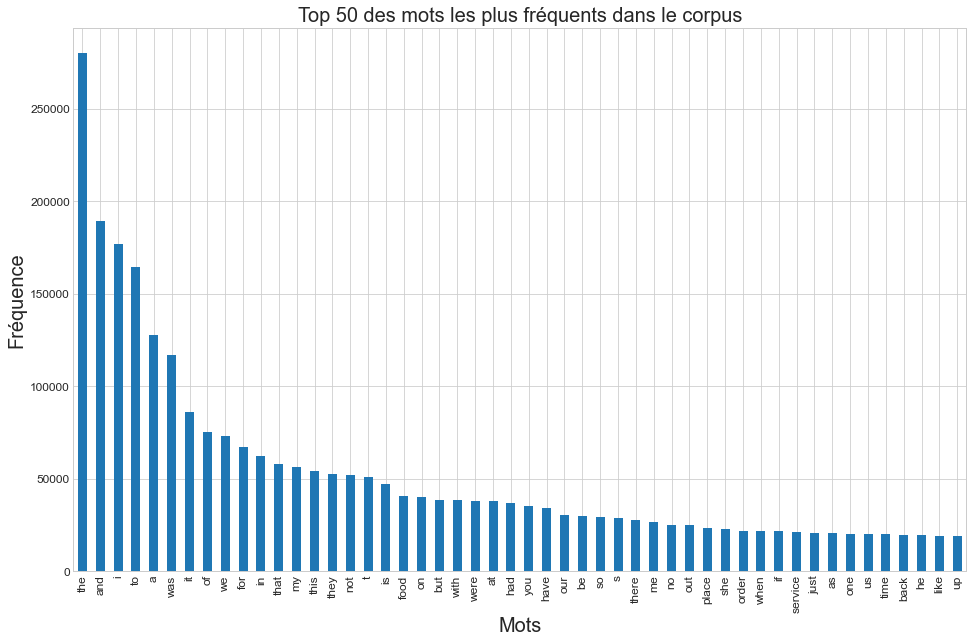

```python
dth.display_word_freq_hist(freq_totale, 50)
```

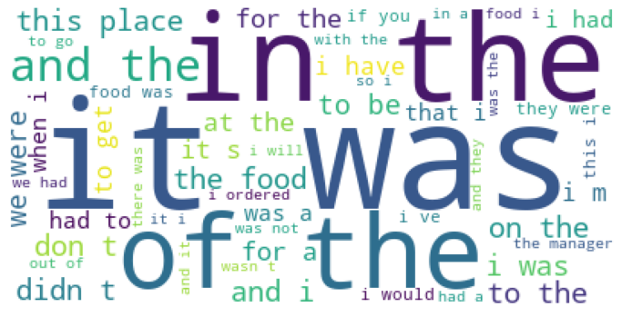

```python
dth.display_wordcloud(corpus, 50)
```

Ce premier nettoyage a permis de supprimer les éléments superflus de nos reviews et de les tokeniser. Le problème est que les mots restants les plus fréquents n'ont pas de sens car ils sont trop communs, il est inutile de les garder.

On va donc procéder à un second nettoyage :

- Supprimer les stop words (les mots communs qui n'ont pas de sens)
- Supprimer les mots de 3 lettres ou moins
- Lemmatiser (récupérer la forme neutre canonique des mots)

2nd Nettoyage :

```python
# Récupération des stop words en Anglais
sw = set()
sw.update(tuple(stopwords.words('english')))
```

```python
lemmatizer = WordNetLemmatizer()

# Création d'un corpus de tokens
corpus_2 = []
for row in sample_reviews.index:
    tokens = tokenize_text(sample_reviews['text'][row])
    corpus_2.append([lemmatizer.lemmatize(w) for w in tokens if w not in sw and len(w) > 3])

# Calcul des fréquences des mots dans chaque texte
freq_2 = []
for row in corpus_2:
    freq_2.append(nltk.FreqDist(row))

# Fréquence totale de chaque mot pour l'ensemble du corpus
freq_totale_2 = nltk.Counter()
for fr in freq_2:
    freq_totale_2 += fr
```

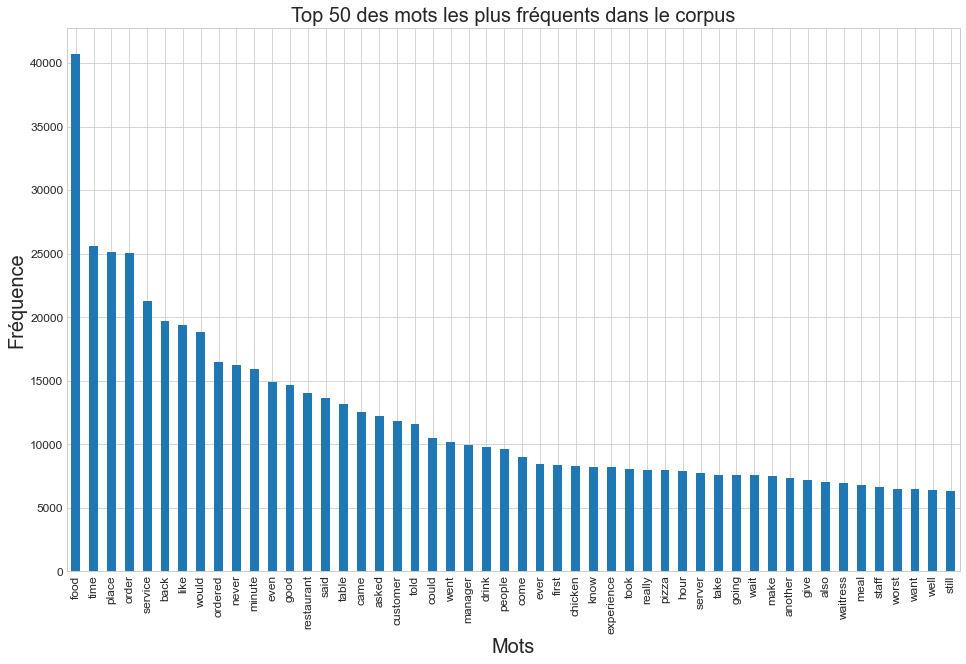

```python
dth.display_word_freq_hist(freq_totale_2, 50)
```

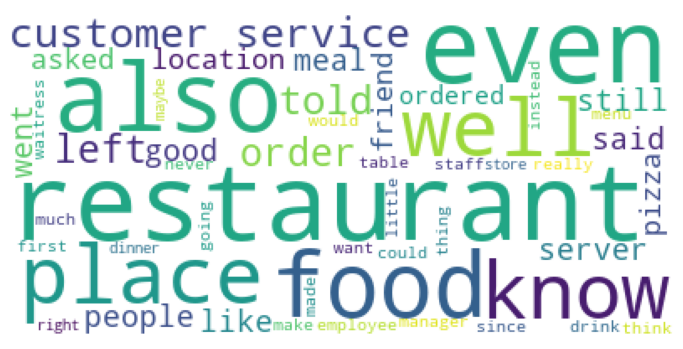

```python
dth.display_wordcloud(corpus_2, 50)
```

Après ce second nettoyage, notre tokenisation a déjà beaucoup plus de sens. Les mots les plus fréquents peuvent être associés à un topic.

Cela nous donne également un aperçu de ce qui ressort le plus souvent dans les mauvaises reviews.

## Vectorisation

Ici on va créer une matrice de taille "nbr reviews * taille du vocabulaire" suivant 2 méthodes :

- CountVectorizer : calculer pour chaque review la fréquence d'apparition des différents mots de tous le vocabulaire
- TfidfVectorizer : calculer pour chaque review un rapport entre la fréquence d'apparition des mots dans la review et dans le corpus total

Ces matrices sont ensuites utilisées par nos algorithmes pour faire par exemple du topic modeling.

On va ici effectuer cette vectorisation à titre d'exemple, car les algorithmes de la librairie Gensim que nous utiliserons par la suite, incluent déjà dans leur pipeline la vectorisation.

```python
def tokenize(text):
    tokens = tokenize_text(text)
    return [lemmatizer.lemmatize(w) for w in tokens if w not in sw and len(w) > 3]
```

```python
cv = CountVectorizer(tokenizer=tokenize, stop_words=sw)
data_cv = cv.fit_transform(sample_reviews['text'])
data_cv_dtm = pd.DataFrame(data_cv.toarray(), columns=cv.get_feature_names_out())
data_cv_dtm.index = sample_reviews.index
data_cv_dtm
```

|  | aaaaaaccccckkkk | aaaaaand | aaand | aaid | aand | aaron | aarp | aback | abacus | abalone | ... | zudar | zukku | zuma | zumbehl | zupas | zuppa | zushi | zwieback | zwischen | zydeco |
| --- | --- | --- | --- | --- | --- | --- | --- | --- | --- | --- | --- | --- | --- | --- | --- | --- | --- | --- | --- | --- | --- |
| 211307 | 0 | 0 | 0 | 0 | 0 | 0 | 0 | 0 | 0 | 0 | ... | 0 | 0 | 0 | 0 | 0 | 0 | 0 | 0 | 0 | 0 |
| 120646 | 0 | 0 | 0 | 0 | 0 | 0 | 0 | 0 | 0 | 0 | ... | 0 | 0 | 0 | 0 | 0 | 0 | 0 | 0 | 0 | 0 |
| 242312 | 0 | 0 | 0 | 0 | 0 | 0 | 0 | 0 | 0 | 0 | ... | 0 | 0 | 0 | 0 | 0 | 0 | 0 | 0 | 0 | 0 |
| 505613 | 0 | 0 | 0 | 0 | 0 | 0 | 0 | 0 | 0 | 0 | ... | 0 | 0 | 0 | 0 | 0 | 0 | 0 | 0 | 0 | 0 |
| 433332 | 0 | 0 | 0 | 0 | 0 | 0 | 0 | 0 | 0 | 0 | ... | 0 | 0 | 0 | 0 | 0 | 0 | 0 | 0 | 0 | 0 |
| ... | ... | ... | ... | ... | ... | ... | ... | ... | ... | ... | ... | ... | ... | ... | ... | ... | ... | ... | ... | ... | ... |
| 511681 | 0 | 0 | 0 | 0 | 0 | 0 | 0 | 0 | 0 | 0 | ... | 0 | 0 | 0 | 0 | 0 | 0 | 0 | 0 | 0 | 0 |
| 296448 | 0 | 0 | 0 | 0 | 0 | 0 | 0 | 0 | 0 | 0 | ... | 0 | 0 | 0 | 0 | 0 | 0 | 0 | 0 | 0 | 0 |
| 421907 | 0 | 0 | 0 | 0 | 0 | 0 | 0 | 0 | 0 | 0 | ... | 0 | 0 | 0 | 0 | 0 | 0 | 0 | 0 | 0 | 0 |
| 596711 | 0 | 0 | 0 | 0 | 0 | 0 | 0 | 0 | 0 | 0 | ... | 0 | 0 | 0 | 0 | 0 | 0 | 0 | 0 | 0 | 0 |
| 164978 | 0 | 0 | 0 | 0 | 0 | 0 | 0 | 0 | 0 | 0 | ... | 0 | 0 | 0 | 0 | 0 | 0 | 0 | 0 | 0 | 0 |

50000 rows × 36810 columns

```python
tfidf = TfidfVectorizer(tokenizer=tokenize, stop_words=sw)
data_tfidf = tfidf.fit_transform(sample_reviews['text'])
data_tfidf_dtm = pd.DataFrame(data_tfidf.toarray(), columns=tfidf.get_feature_names_out())
data_tfidf_dtm.index = sample_reviews.index
data_tfidf_dtm
```

|  | aaaaaaccccckkkk | aaaaaand | aaand | aaid | aand | aaron | aarp | aback | abacus | abalone | ... | zudar | zukku | zuma | zumbehl | zupas | zuppa | zushi | zwieback | zwischen | zydeco |
| --- | --- | --- | --- | --- | --- | --- | --- | --- | --- | --- | --- | --- | --- | --- | --- | --- | --- | --- | --- | --- | --- |
| 211307 | 0.0 | 0.0 | 0.0 | 0.0 | 0.0 | 0.0 | 0.0 | 0.0 | 0.0 | 0.0 | ... | 0.0 | 0.0 | 0.0 | 0.0 | 0.0 | 0.0 | 0.0 | 0.0 | 0.0 | 0.0 |
| 120646 | 0.0 | 0.0 | 0.0 | 0.0 | 0.0 | 0.0 | 0.0 | 0.0 | 0.0 | 0.0 | ... | 0.0 | 0.0 | 0.0 | 0.0 | 0.0 | 0.0 | 0.0 | 0.0 | 0.0 | 0.0 |
| 242312 | 0.0 | 0.0 | 0.0 | 0.0 | 0.0 | 0.0 | 0.0 | 0.0 | 0.0 | 0.0 | ... | 0.0 | 0.0 | 0.0 | 0.0 | 0.0 | 0.0 | 0.0 | 0.0 | 0.0 | 0.0 |
| 505613 | 0.0 | 0.0 | 0.0 | 0.0 | 0.0 | 0.0 | 0.0 | 0.0 | 0.0 | 0.0 | ... | 0.0 | 0.0 | 0.0 | 0.0 | 0.0 | 0.0 | 0.0 | 0.0 | 0.0 | 0.0 |
| 433332 | 0.0 | 0.0 | 0.0 | 0.0 | 0.0 | 0.0 | 0.0 | 0.0 | 0.0 | 0.0 | ... | 0.0 | 0.0 | 0.0 | 0.0 | 0.0 | 0.0 | 0.0 | 0.0 | 0.0 | 0.0 |
| ... | ... | ... | ... | ... | ... | ... | ... | ... | ... | ... | ... | ... | ... | ... | ... | ... | ... | ... | ... | ... | ... |
| 511681 | 0.0 | 0.0 | 0.0 | 0.0 | 0.0 | 0.0 | 0.0 | 0.0 | 0.0 | 0.0 | ... | 0.0 | 0.0 | 0.0 | 0.0 | 0.0 | 0.0 | 0.0 | 0.0 | 0.0 | 0.0 |
| 296448 | 0.0 | 0.0 | 0.0 | 0.0 | 0.0 | 0.0 | 0.0 | 0.0 | 0.0 | 0.0 | ... | 0.0 | 0.0 | 0.0 | 0.0 | 0.0 | 0.0 | 0.0 | 0.0 | 0.0 | 0.0 |
| 421907 | 0.0 | 0.0 | 0.0 | 0.0 | 0.0 | 0.0 | 0.0 | 0.0 | 0.0 | 0.0 | ... | 0.0 | 0.0 | 0.0 | 0.0 | 0.0 | 0.0 | 0.0 | 0.0 | 0.0 | 0.0 |
| 596711 | 0.0 | 0.0 | 0.0 | 0.0 | 0.0 | 0.0 | 0.0 | 0.0 | 0.0 | 0.0 | ... | 0.0 | 0.0 | 0.0 | 0.0 | 0.0 | 0.0 | 0.0 | 0.0 | 0.0 | 0.0 |
| 164978 | 0.0 | 0.0 | 0.0 | 0.0 | 0.0 | 0.0 | 0.0 | 0.0 | 0.0 | 0.0 | ... | 0.0 | 0.0 | 0.0 | 0.0 | 0.0 | 0.0 | 0.0 | 0.0 | 0.0 | 0.0 |

50000 rows × 36810 columns

## Topic Modeling avec LDA (Latent Dirichlet Allocation)

On veut identifier des topics à partir des reviews pour essayer de comprendre ce qui rend les clients insatisfaits.

On va utiliser la technique LDA (Laten Dirichlet Allocation).

```python
# Create a corpus from a list of texts
common_dictionary = Dictionary(corpus_2)
common_corpus = [common_dictionary.doc2bow(text) for text in corpus_2]
```

Cet algorithme prend en entrée un hyperparamètre "num_topics" permettant de définir le nombre de topics que l'on veut extraire.

Il est possible d'identifier un nombre idéal de topics, que l'on verra un peu plus loin.

On va commencer ici avec 4 topics.

### 1er Essai

```python
lda = models.LdaModel(corpus=common_corpus, id2word=common_dictionary, num_topics=4)
lda.print_topics()
```

```
[(0,
  '0.020*"place" + 0.013*"food" + 0.011*"like" + 0.007*"good" + 0.006*"time" + 0.006*"restaurant" + 0.005*"room" + 0.005*"people" + 0.005*"staff" + 0.005*"really"'),
 (1,
  '0.016*"chicken" + 0.015*"like" + 0.014*"ordered" + 0.011*"cheese" + 0.010*"sandwich" + 0.010*"sauce" + 0.008*"meat" + 0.007*"fry" + 0.007*"burger" + 0.007*"taste"'),
 (2,
  '0.036*"food" + 0.013*"service" + 0.012*"place" + 0.012*"time" + 0.012*"ordered" + 0.011*"good" + 0.011*"came" + 0.010*"table" + 0.009*"restaurant" + 0.009*"back"'),
 (3,
  '0.018*"order" + 0.014*"time" + 0.011*"said" + 0.011*"customer" + 0.011*"minute" + 0.011*"service" + 0.010*"would" + 0.010*"back" + 0.010*"told" + 0.009*"never"')]
```

```python
# Perplexity
print('\nPerplexity: ', lda.log_perplexity(common_corpus))  # a measure of how good the model is. lower the better.

# Coherence Score
coherence_model_lda = models.CoherenceModel(model=lda, texts=corpus_2, dictionary=common_dictionary, coherence='c_v')
coherence_lda = coherence_model_lda.get_coherence()
print('\nCoherence Score: ', coherence_lda)
```

```
Perplexity:  -7.471341134108927

Coherence Score:  0.3897148879471353
```

Plus le Coherence Score est proche de 1, meilleure est notre modélisation.

```python
# Visualisation des topics
pyLDAvis.enable_notebook()
pyLDAvis.gensim_models.prepare(lda, common_corpus, common_dictionary)
```

[interactive chart not shown]

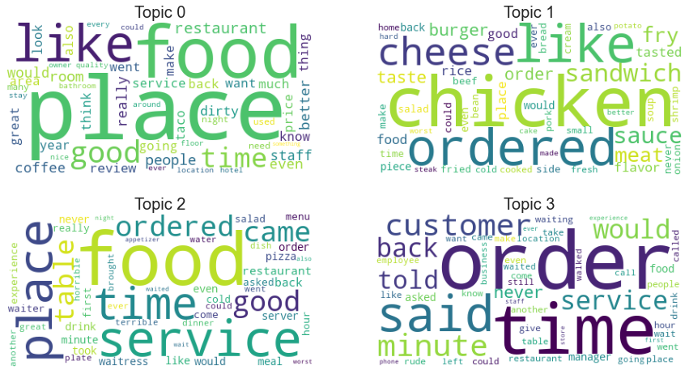

```python
# On affiche le nuage de mots de chaque topic
nbr_rows = int(lda.num_topics/2) if lda.num_topics % 2 == 0 else int((lda.num_topics+1)/2)
index = 1

fig, axs = plt.subplots(nbr_rows, 2, figsize=(15,4*nbr_rows))

for t in range(lda.num_topics):
    plt.subplot(nbr_rows, 2, index)
    plt.imshow(WordCloud(background_color = 'white').fit_words(dict(lda.show_topic(t, 50))))
    plt.axis("off")
    plt.title("Topic " + str(t))

    index+=1

plt.show()
```

Avec cette technique et à l'aide des graphiques on peut donc identifier à quoi correspondent les 4 topics :

- Topic 0 : food, place, restaurant, like, good, time (Le lieu ?)
- Topic 1 : chicken, ordered, cheese, sandwich, like, meat (La nourriture ?)
- Topic 2 : food, time, service, place, ordered, came, good (La commande et le temps ?)
- Topic 3 : order, time, service, customer, minute (Le service ?)

On pourrait améliorer la précision en supprimant certains mots qui ne sont pas utiles pour faire du Topic Modeling.

### 2ème Essai

On va ici retravailler notre corpus en complétant le nettoyage des reviews de notre jeu de données :

- On garde seulement les noms

```python
lemmatizer = WordNetLemmatizer()

# Création d'un corpus de tokens
corpus_3 = []
for row in sample_reviews.index:
    tokens = tokenize_text(sample_reviews['text'][row])
    corpus_3.append([lemmatizer.lemmatize(w) for w in tokens if w not in sw and len(w) > 3])

# On garde seulement les noms
corpus_3_cleaned = []
for element in corpus_3:
    pos_tag = nltk.pos_tag(element)
    if len(pos_tag) > 1:
        pos_tag_cleaned = list(zip(*[word for word in pos_tag if word[1] == 'NN']))
        if len(pos_tag_cleaned) > 1 :
            corpus_3_cleaned.append(list(pos_tag_cleaned[0]))

# Calcul des fréquences des mots dans chaque texte
freq_3 = []
for row in corpus_3_cleaned:
    freq_3.append(nltk.FreqDist(row))

# Fréquence totale de chaque mot pour l'ensemble du corpus
freq_totale_3 = nltk.Counter()
for fr in freq_3:
    freq_totale_3 += fr
```

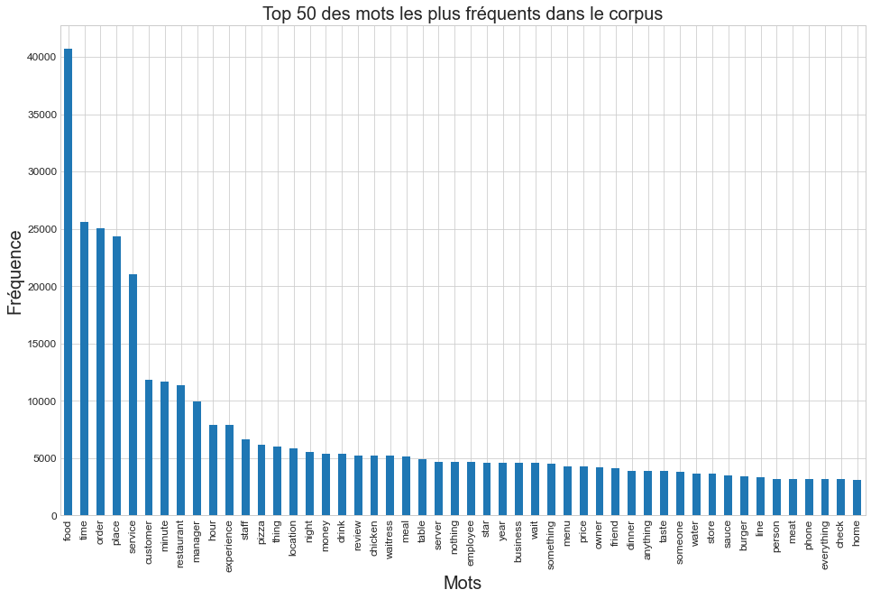

```python
dth.display_word_freq_hist(freq_totale_3, 50)
```

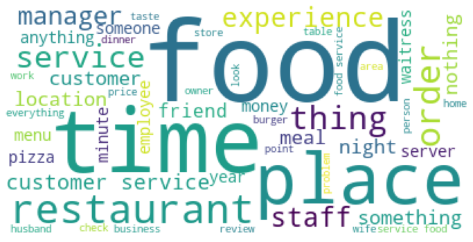

```python
dth.display_wordcloud(corpus_3_cleaned, 50)
```

Voici à quoi ressemble la distribution des noms les plus courants

On va maintenant utiliser la technique LDA sur ce nouveau corpus. On va déterminer quel est le meilleur hyperparamètre nump_topic à prendre en fonction du coherence score

```python
# Calcul le coherence score pour plusieurs valeurs de l'hyperparamètres num_topic
def compute_coherence_values(dictionnary, corpus, texts):

    coherences_values = []
    model_list = []

    for num_topic in range(2, 21, 1):
        model = models.LdaModel(corpus=corpus, id2word=dictionnary, num_topics=num_topic)
        model_list.append(model)

        coherence_model = models.CoherenceModel(model=model, texts=texts, dictionary=dictionnary, coherence='c_v')
        coherences_values.append(coherence_model.get_coherence())

    return model_list, coherences_values
```

```python
# Create a corpus from a list of texts
common_dictionary = Dictionary(corpus_3_cleaned)
common_corpus = [common_dictionary.doc2bow(text) for text in corpus_3_cleaned]

model_list, coherence_values = compute_coherence_values(common_dictionary, common_corpus, corpus_3_cleaned)
```

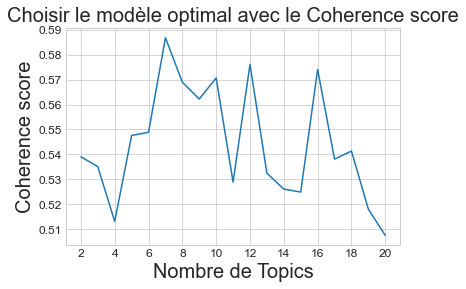

```python
# Graphe d'évolution du coherence score
x = range(2, 21, 1)
plt.plot(x, coherence_values)
plt.xticks(range(2, 21, 2))
plt.xlabel("Nombre de Topics")
plt.ylabel("Coherence score")
plt.title("Choisir le modèle optimal avec le Coherence score")
plt.show()
```

La différence de coherence score en fonction du nombre de topics n'est pas si grande. Elle augmente à partir de 6 et commence à chuter après une dizaine de topics.

Pour la suite on va prendre un nombre de topics à 6.

```python
lda = model_list[4]
lda.print_topics()
```

```
[(0,
  '0.073*"food" + 0.038*"service" + 0.032*"time" + 0.026*"minute" + 0.023*"order" + 0.019*"waitress" + 0.019*"restaurant" + 0.018*"server" + 0.017*"drink" + 0.017*"place"'),
 (1,
  '0.023*"food" + 0.023*"place" + 0.020*"coffee" + 0.018*"staff" + 0.014*"customer" + 0.013*"manager" + 0.013*"owner" + 0.011*"restaurant" + 0.011*"business" + 0.010*"time"'),
 (2,
  '0.061*"order" + 0.039*"time" + 0.036*"customer" + 0.030*"service" + 0.020*"place" + 0.018*"food" + 0.015*"location" + 0.015*"manager" + 0.014*"store" + 0.013*"minute"'),
 (3,
  '0.041*"food" + 0.027*"place" + 0.023*"chicken" + 0.020*"burger" + 0.018*"meat" + 0.017*"taste" + 0.016*"sauce" + 0.014*"flavor" + 0.013*"fry" + 0.013*"time"'),
 (4,
  '0.028*"time" + 0.027*"place" + 0.024*"room" + 0.017*"reservation" + 0.017*"night" + 0.016*"hour" + 0.015*"minute" + 0.013*"door" + 0.012*"restaurant" + 0.010*"order"'),
 (5,
  '0.050*"food" + 0.044*"pizza" + 0.037*"place" + 0.018*"restaurant" + 0.016*"roll" + 0.013*"rice" + 0.013*"order" + 0.011*"sushi" + 0.011*"chicken" + 0.010*"time"')]
```

```python
# Perplexity
print('\nPerplexity: ', lda.log_perplexity(common_corpus))  # a measure of how good the model is. lower the better.

# Coherence Score
coherence_model_lda = models.CoherenceModel(model=lda, texts=corpus_3_cleaned, dictionary=common_dictionary, coherence='c_v')
coherence_lda = coherence_model_lda.get_coherence()
print('\nCoherence Score: ', coherence_lda)
```

```
Perplexity:  -6.953915725940225

Coherence Score:  0.548873972366418
```

```python
# Visualisation des topics
pyLDAvis.enable_notebook()
pyLDAvis.gensim_models.prepare(lda, common_corpus, common_dictionary)
```

[interactive chart not shown]

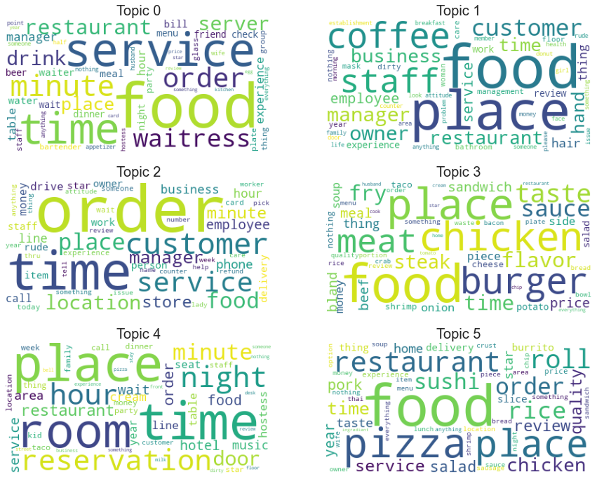

```python
# On affiche le nuage de mots de chaque topic
nbr_rows = int(lda.num_topics/2) if lda.num_topics % 2 == 0 else int((lda.num_topics+1)/2)
index = 1

fig, axs = plt.subplots(nbr_rows, 2, figsize=(15,4*nbr_rows))

for t in range(lda.num_topics):
    plt.subplot(nbr_rows, 2, index)
    plt.imshow(WordCloud(background_color = 'white').fit_words(dict(lda.show_topic(t, 50))))
    plt.axis("off")
    plt.title("Topic " + str(t))

    index+=1

plt.show()
```

Voici à quoi correspondent les 6 topics :

- Topic 0 : food, service, time, minute, order, waitress (Temps de service)
- Topic 1 : place, food, coffee, staff, customer, manager, employee (Le personnel)
- Topic 2 : order, time, service, customer, place, location (Le lieu et le service)
- Topic 3 : chicken, burger, meat, steak, taste, fry (Nourriture)
- Topic 4 : place, room, reservation, hour, night, minute (Horaire et lieu)
- Topic 5 : food, pizza, place, restaurant, sushi, rice, roll (Nourriture)

Globalement les clients sont donc insatisfaits à propos de :

- Du restaurant
- Du service
- Du temps de service
- Du personnel
- Du prix
- De la nourriture